# Data Analayst Intern Test

Dwi Putri Ivane

2024-12-19

## Exploring Online Retail Revenue: A Detailed Analysis of Transactions and Trends

> The goal of this analysis is to explore key trends and patterns in online retail transactions, with a focus on understanding revenue generation across different time periods, product categories, and customer segments. The insights derived from this analysis will help develop strategies to optimize sales, improve customer targeting, and enhance business performance for an online retail company.

Below is the detailed process I followed, which includes the six phases of data analysis covered in the course: 1) ask, 2) prepare, 3) process, 4) analyze, 5) share, and 6) act.

### ASK

#### Background

The data was provided by [UCI Machine Learning](https://archive.ics.uci.edu/dataset/352/online+retail). This is a transactional data set which contains all the transactions occurring between 01/12/2010 and 09/12/2011 for a UK-based and registered non-store online retail.The company mainly sells unique all-occasion gifts. Many customers of the company are wholesalers.

#### Business Task

The business task for this analysis is to identify key revenue trends, top-performing products, and customer behaviors in an online retail setting. By examining transaction data across different time periods and product categories, the goal is to provide actionable insights that can help optimize sales strategies, improve inventory management, and enhance overall business performance.

#### Defining Problem

1. What are the top 10 products by quantity sold?
2. What are the top 10 products by revenue?
3. How does the monthly revenue trend over time?
4. Which 10 countries contribute the most to the overall revenue?
5. What is the average revenue per customer, and who are the high-value customers?
6. What is the heatmap showing the relationship between month, day, and total revenue?

### PREPARE

#### Data Source

The data was provided by [UCI Machine Learning](https://archive.ics.uci.edu/dataset/352/online+retail).

| <sub>variable name</sub> | <sub>type</sub> | <sub>description</sub> |
| --- | --- | --- |
| <sub>InvoiceNo</sub> | <sub>categorical</sub> | <sub>integral number uniquely assigned to each transaction.</sub> |
| <sub>StockCode</sub> | <sub>categorical</sub> | <sub>integral number uniquely assigned to each distinct product</sub> |
| <sub>Description</sub> | <sub>categorical</sub> | <sub>product name</sub> |
| <sub>Quantity</sub> | <sub>integer</sub> | <sub>the quantities of each product (item) per transaction</sub> |
| <sub>InvoiceDate</sub> | <sub>date</sub> | <sub>the day and time when each transaction was generated</sub> |
| <sub>UnitPrice</sub> | <sub>continuous</sub> | <sub>product price per unit</sub> |
| <sub>CustomerID</sub> | <sub>categorical</sub> | <sub>integral number uniquely assigned to each customer</sub> |
| <sub>Country</sub> | <sub>categorical</sub> | <sub>the name of the country where each customer resides</sub> |

#### ROCCC Verification

- **reliable**: the dataset is accurate and derived directly from online retail transactions, capturing detailed sales data.
- **original**: the data is collected firsthand from online retail system, making it highly original and trustworthy.
- **comprehensive**: the dataset is moderately comprehensive.
- **current**: the data covers transactions from December 2010 to December 2011.
- **cited**: the dataset orginates from the UCI Machine Learning Repository, ensuring credibility as it is widely recognized and used for educational research purpose.

### PROCESS

#### Data Analysis Tools

RStudio is being used as the primary data analysis tools to process, clean, and visualize the dataset.

#### Setting up and importing the dataset

```r
# Set working directory to the folder containing your Excel file
setwd("C:/Users/Lenovo/Downloads/dataanalysttest")

# Load required library
library(readxl)
library(dplyr)
library(skimr)
library(lubridate)
```

```r
library(ggplot2)

# Read the XLSX file into R
data <- read_excel("onlineretail.xlsx", sheet = 1)

# View the first few rows of the data
head(data)
```

```
## # A tibble: 6 × 8
##   InvoiceNo StockCode Description         Quantity InvoiceDate         UnitPrice
##   <chr>     <chr>     <chr>                  <dbl> <dttm>                  <dbl>
## 1 536365    85123A    WHITE HANGING HEAR…        6 2010-12-01 08:26:00      2.55
## 2 536365    71053     WHITE METAL LANTERN        6 2010-12-01 08:26:00      3.39
## 3 536365    84406B    CREAM CUPID HEARTS…        8 2010-12-01 08:26:00      2.75
## 4 536365    84029G    KNITTED UNION FLAG…        6 2010-12-01 08:26:00      3.39
## 5 536365    84029E    RED WOOLLY HOTTIE …        6 2010-12-01 08:26:00      3.39
## 6 536365    22752     SET 7 BABUSHKA NES…        2 2010-12-01 08:26:00      7.65
## # ℹ 2 more variables: CustomerID <dbl>, Country <chr>
```

#### Check for missing values

```r
sapply(data, function(x) sum(is.na(x)))
```

```
##   InvoiceNo   StockCode Description    Quantity InvoiceDate   UnitPrice
##           0           0        1454           0           0           0
##  CustomerID     Country
##      135080           0
```

column such as CustomerID might have missing values, which could indicate either guest or incomplete transaction.

#### Filter out invalid data

```r
cleaned_data <- data %>%
  filter(!is.na(CustomerID), Quantity>0, UnitPrice>0)

# View the first few rows of the data
head(cleaned_data)
```

```
## # A tibble: 6 × 8
##   InvoiceNo StockCode Description         Quantity InvoiceDate         UnitPrice
##   <chr>     <chr>     <chr>                  <dbl> <dttm>                  <dbl>
## 1 536365    85123A    WHITE HANGING HEAR…        6 2010-12-01 08:26:00      2.55
## 2 536365    71053     WHITE METAL LANTERN        6 2010-12-01 08:26:00      3.39
## 3 536365    84406B    CREAM CUPID HEARTS…        8 2010-12-01 08:26:00      2.75
## 4 536365    84029G    KNITTED UNION FLAG…        6 2010-12-01 08:26:00      3.39
## 5 536365    84029E    RED WOOLLY HOTTIE …        6 2010-12-01 08:26:00      3.39
## 6 536365    22752     SET 7 BABUSHKA NES…        2 2010-12-01 08:26:00      7.65
## # ℹ 2 more variables: CustomerID <dbl>, Country <chr>
```

#### Add revenue and time features

```r
cleaned_data <- cleaned_data %>%
  mutate(
    Revenue = Quantity*UnitPrice,
    Year=year(InvoiceDate),
    Month=month(InvoiceDate),
    Day=day(InvoiceDate),
    Hour=hour(InvoiceDate)
  )

# View the first few rows of the data
head(cleaned_data)
```

```
## # A tibble: 6 × 13
##   InvoiceNo StockCode Description         Quantity InvoiceDate         UnitPrice
##   <chr>     <chr>     <chr>                  <dbl> <dttm>                  <dbl>
## 1 536365    85123A    WHITE HANGING HEAR…        6 2010-12-01 08:26:00      2.55
## 2 536365    71053     WHITE METAL LANTERN        6 2010-12-01 08:26:00      3.39
## 3 536365    84406B    CREAM CUPID HEARTS…        8 2010-12-01 08:26:00      2.75
## 4 536365    84029G    KNITTED UNION FLAG…        6 2010-12-01 08:26:00      3.39
## 5 536365    84029E    RED WOOLLY HOTTIE …        6 2010-12-01 08:26:00      3.39
## 6 536365    22752     SET 7 BABUSHKA NES…        2 2010-12-01 08:26:00      7.65
## # ℹ 7 more variables: CustomerID <dbl>, Country <chr>, Revenue <dbl>,
## #   Year <dbl>, Month <dbl>, Day <int>, Hour <int>
```

### ANALYZE

#### The top 10 products by quantity sold

```r
top_product <- cleaned_data %>%
  group_by(Description) %>%
  summarize(TotalQuantity=sum(Quantity)) %>%
  arrange(desc(TotalQuantity)) %>%
  head(10)

top_product
```

```
## # A tibble: 10 × 2
##    Description                        TotalQuantity
##    <chr>                                      <dbl>
##  1 PAPER CRAFT , LITTLE BIRDIE                80995
##  2 MEDIUM CERAMIC TOP STORAGE JAR             77916
##  3 WORLD WAR 2 GLIDERS ASSTD DESIGNS          54415
##  4 JUMBO BAG RED RETROSPOT                    46181
##  5 WHITE HANGING HEART T-LIGHT HOLDER         36725
##  6 ASSORTED COLOUR BIRD ORNAMENT              35362
##  7 PACK OF 72 RETROSPOT CAKE CASES            33693
##  8 POPCORN HOLDER                             30931
##  9 RABBIT NIGHT LIGHT                         27202
## 10 MINI PAINT SET VINTAGE                     26076
```

This table lists the top 10 products by quantity sold, showing their descriptions and total quantities. The highest-selling item is “PAPER CRAFT, LITTLE BIRDIE” with 80,995 units, followed by “MEDIUM CERAMIC TOP STORAGE JAR” with 77,916 units. Other popular items include various decorative and practical products like “WORLD WAR 2 GLIDERS ASSTD DESIGNS” and “JUMBO BAG RED RETROSPOT.”

#### The top 10 products by revenue

```r
top_revenue_products <- cleaned_data %>%
  group_by(Description) %>%
  summarize(TotalRevenue=sum(Revenue)) %>%
  arrange(desc(TotalRevenue)) %>%
  head(10)

top_revenue_products
```

```
## # A tibble: 10 × 2
##    Description                        TotalRevenue
##    <chr>                                     <dbl>
##  1 PAPER CRAFT , LITTLE BIRDIE             168470.
##  2 REGENCY CAKESTAND 3 TIER                142593.
##  3 WHITE HANGING HEART T-LIGHT HOLDER      100448.
##  4 JUMBO BAG RED RETROSPOT                  85221.
##  5 MEDIUM CERAMIC TOP STORAGE JAR           81417.
##  6 POSTAGE                                  77804.
##  7 PARTY BUNTING                            68844.
##  8 ASSORTED COLOUR BIRD ORNAMENT            56580.
##  9 Manual                                   53780.
## 10 RABBIT NIGHT LIGHT                       51346.
```

This table highlights the top 10 products by total revenue. The highest revenue was generated by “PAPER CRAFT, LITTLE BIRDIE” at $168,469.60, followed by “REGENCY CAKESTAND 3 TIER” with $142,592.95. Other high-revenue products include “WHITE HANGING HEART T-LIGHT HOLDER” and “JUMBO BAG RED RETROSPOT,” showcasing a mix of decorative and functional items.

#### Monthly revenue trend over time

```r
monthly_revenue <- cleaned_data %>%
  group_by(Year, Month) %>%
  summarize(TotalRevenue=sum(Revenue), .groups = 'drop')

monthly_revenue
```

```
## # A tibble: 13 × 3
##     Year Month TotalRevenue
##    <dbl> <dbl>        <dbl>
##  1  2010    12      572714.
##  2  2011     1      569445.
##  3  2011     2      447137.
##  4  2011     3      595501.
##  5  2011     4      469200.
##  6  2011     5      678595.
##  7  2011     6      661214.
##  8  2011     7      600091.
##  9  2011     8      645344.
## 10  2011     9      952838.
## 11  2011    10     1039319.
## 12  2011    11     1161817.
## 13  2011    12      518193.
```

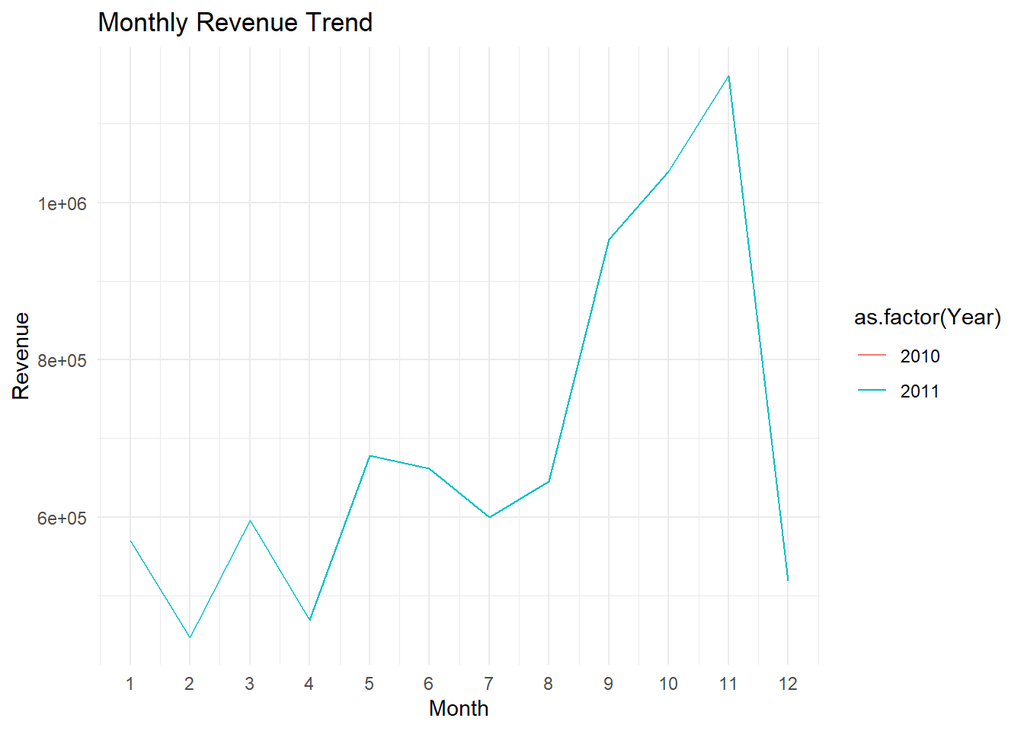

```r
ggplot(monthly_revenue, aes(x=Month, y=TotalRevenue, color=as.factor(Year))) +
  geom_line() +
  scale_x_continuous(breaks = 1:12) +
  labs(
    title="Monthly Revenue Trend",
    x="Month",
    y="Revenue") +
  theme_minimal()
```

The revenue data for 2010 only includes December, which is why the trend for that year is not fully visible. However, the revenue trend for 2011 shows a general upward trajectory from the beginning of the year, reaching its peak in November. The decline in December 2011 is likely due to incomplete data, as it does not account for sales through the end of the month. It can be anticipated that December’s revenue would continue to rise, given the higher likelihood of purchases for decorations and other festive events during this period.

#### Top 10 countries contribute the most to the overall revenue

```r
top_countries <- cleaned_data %>%
  group_by(Country) %>%
  summarize(TotalRevenue=sum(Revenue)) %>%
  arrange(desc(TotalRevenue)) %>%
  head(10)

top_countries
```

```
## # A tibble: 10 × 2
##    Country        TotalRevenue
##    <chr>                 <dbl>
##  1 United Kingdom     7308392.
##  2 Netherlands         285446.
##  3 EIRE                265546.
##  4 Germany             228867.
##  5 France              209024.
##  6 Australia           138521.
##  7 Spain                61577.
##  8 Switzerland          56444.
##  9 Belgium              41196.
## 10 Sweden               38378.
```

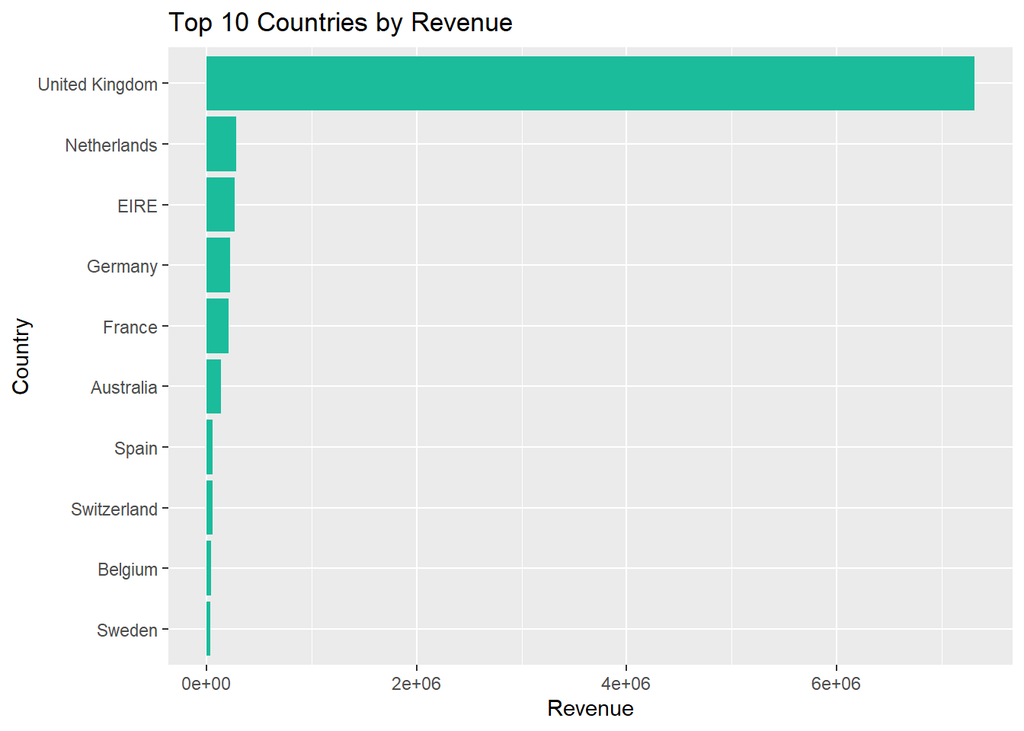

```r
ggplot(top_countries,aes(x=reorder(Country, TotalRevenue), y=TotalRevenue)) +
  geom_bar(stat="identity", fill="#1ABC9C") +
  coord_flip() +
  labs(title = "Top 10 Countries by Revenue", x="Country", y="Revenue")
```

```r
customer_revenue <- cleaned_data %>%
  group_by(CustomerID) %>%
  summarize(
    TotalRevenue=sum(Revenue),
    TotalQuantity=sum(Quantity),
    NumInvoice=n_distinct(InvoiceNo)
  ) %>%
  arrange(desc(TotalRevenue))

customer_revenue
```

```
## # A tibble: 4,338 × 4
##    CustomerID TotalRevenue TotalQuantity NumInvoice
##         <dbl>        <dbl>         <dbl>      <int>
##  1      14646      280206.        196915         73
##  2      18102      259657.         64124         60
##  3      17450      194551.         69993         46
##  4      16446      168472.         80997          2
##  5      14911      143825.         80265        201
##  6      12415      124915.         77374         21
##  7      14156      117380.         57885         55
##  8      17511       91062.         64549         31
##  9      16029       81025.         40208         63
## 10      12346       77184.         74215          1
## # ℹ 4,328 more rows
```

This table summarizes the total revenue, quantity, and number of invoices for each customer. The customer with ID 14646 generated the highest revenue of $280,206.02, followed by customer 18102 with $259,657.30. Other top customers include customer 17450 with $194,550.79 and customer 16446 with $168,472.50. The data highlights the total quantity purchased and the number of distinct invoices for each customer, showcasing their purchasing behavior.

#### Heatmap showing the relationship between month, day, and total revenue

```r
#drop data from 2010
cleaned_data_filtered <- cleaned_data %>%
  filter(Year != 2010)

heatmap <- cleaned_data_filtered %>%
  group_by(Month, Day) %>%
  summarize(TotalRevenue = sum(Revenue), .groups = 'drop')

heatmap
```

```
## # A tibble: 285 × 3
##    Month   Day TotalRevenue
##    <dbl> <int>        <dbl>
##  1     1     4       12125.
##  2     1     5       28804.
##  3     1     6       34360.
##  4     1     7       23798.
##  5     1     9       15778.
##  6     1    10       15347.
##  7     1    11       60269.
##  8     1    12       17154.
##  9     1    13       15171.
## 10     1    14       39532.
## # ℹ 275 more rows
```

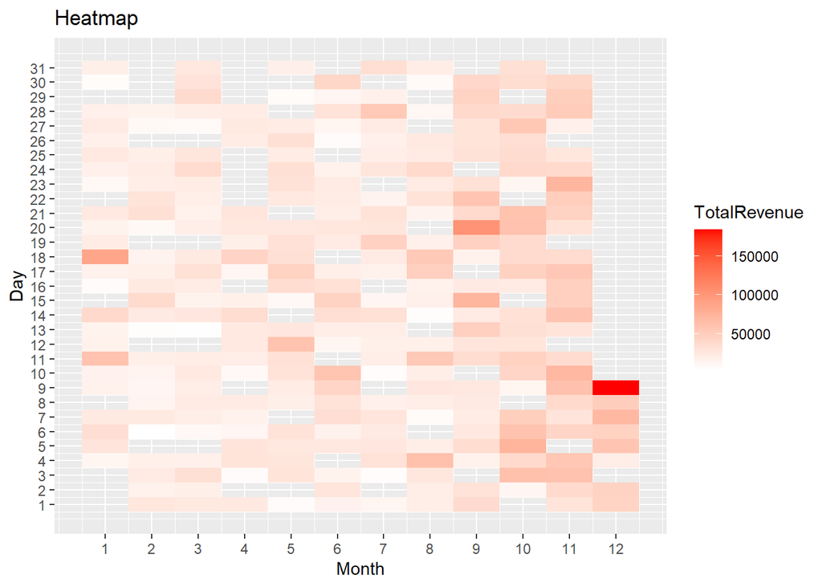

```r
ggplot(heatmap, aes(x = Month, y = Day, fill = TotalRevenue)) +
  geom_tile() +
  scale_fill_gradient(low = "white", high = "red") +
  scale_x_continuous(breaks = 1:12) +
  scale_y_continuous(breaks = seq(1, 31, by = 1)) +
  labs(x = "Month", y = "Day", title = "Heatmap")
```